# Logistic Regression

R. Noah Padgett

4/2/2018

Initialize:

```r
library("phyloseq"); packageVersion("phyloseq")
```

```
## [1] '1.22.3'
```

```r
library("ggplot2"); packageVersion("ggplot2")
```

```
## [1] '2.2.1'
```

```r
library("gridExtra")
library(grid)
library(picante)
library("igraph"); packageVersion("igraph")
```

```
## [1] '1.2.1'
```

```r
library(dplyr, tidyr)
library(kableExtra)
library(lavaan)
library(data.table)
set.seed(20180116)
default.par <- par(no.readonly = TRUE)
options(stringsAsFactors = FALSE)
theme_set(theme_bw())
```

Load data:

```r
# Set working directory to source file location
setwd("~/Box Sync/Research/CRC BMI Meta/Compiled Code & Results/Alpha Diversity")
load("~/Box Sync/Research/CRC BMI Meta/Compiled Code & Results/Data/CRC_BMI_DATA.RData")
```

# Estimate Alpha diversity

```r
# Estimate alpha diversity metrics: this loop also combines the etimates
# with the sample data to create a dataframe for each study that includes
# alpha diversity
datasets <- names(myphylo)
data <- list()
for (df in datasets) {
    # df <- 'baxter'
    dat <- prune_species(speciesSums(myphylo[[df]]) > 1, myphylo[[df]])

    est_alpha <- estimate_richness(dat, measures = c("Observed", "Shannon",
        "InvSimpson"))
    data[[df]] <- cbind(sample_data(dat), est_alpha)
}
```

## Logistic Regression Models

The logistic regression model aims to predict the probability of the outcome variable being a 1. So, in this case, 1 is the the identifer we use to denote an individual has CRC and 0 represents a non-CRC individual. Therefore, let Y = 1 if an individual has CRC or Y = 0 otherwise. We are only interesting in obese individuals as well, so the dataset will be subsetted to only these individuals.

$$\log \frac{Pr(Y_i = 1)}{1 - Pr(Y_i = 1)} = a_j$$

where the logit (a) varies based on the study being analyzed.

```r
# subset to obese individuals only & create a binary ID variable for status
for (df in datasets) {
    if (df == "pooled") {
        pooled.dat <- data[[df]]
        pooled.dat$Obese <- ifelse(pooled.dat$BMI_Cat == "Obese", 1, 0)  # Recoding for ease of interpreation
        pooled.dat$CRC <- ifelse(pooled.dat$Status == "CRC", 1, 0)
    }
    # For subsetting
    data[[df]] <- data[[df]][data[[df]]$BMI_Cat == "Obese", ]
    data[[df]]$CRC <- ifelse(data[[df]]$Status == "CRC", 1, 0)
}

# Formulas:
fobs <- paste0("CRC ~ Observed + BMI + Age + Gender")
fshan <- paste0("CRC ~ Shannon + BMI + Age + Gender")
```

### Baxter

```r
# Observed OTUs
baxter.otu <- glm(fobs, data = data[["baxter"]], family = "binomial")

# Shannon Index
baxter.shan <- glm(fshan, data = data[["baxter"]], family = "binomial")
```

### Feng

```r
# Observed OTUs
feng.otu <- glm(fobs, data = data[["feng"]], family = "binomial")

# Shannon Index
feng.shan <- glm(fshan, data = data[["feng"]], family = "binomial")
```

### Voghtmann

```r
# Observed OTUs
voghtmann.otu <- glm(fobs, data = data[["voghtmann"]], family = "binomial")

# Shannon Index
voghtmann.shan <- glm(fshan, data = data[["voghtmann"]], family = "binomial")
```

### Zackular

```r
# Observed OTUs
zackular.otu <- glm(fobs, data = data[["zackular"]], family = "binomial")

# Shannon Index
zackular.shan <- glm(fshan, data = data[["zackular"]], family = "binomial")
```

### Zeller A: Stool

```r
# Observed OTUs
zeller.Stool.otu <- glm(fobs, data = data[["zeller.Stool"]], family = "binomial")

# Shannon Index
zeller.Stool.shan <- glm(fshan, data = data[["zeller.Stool"]], family = "binomial")
out <- glm(fshan, data = pooled.dat[pooled.dat$Study == "zeller.stool", ], family = "binomial")
summary(out)
```

```
##
## Call:
## glm(formula = fshan, family = "binomial", data = pooled.dat[pooled.dat$Study ==
##     "zeller.stool", ])
##
## Deviance Residuals:
##     Min       1Q   Median       3Q      Max
## -1.1925  -0.8985  -0.8113   1.3635   1.8441
##
## Coefficients:
##              Estimate Std. Error z value Pr(>|z|)
## (Intercept) -3.628383   2.273053  -1.596   0.1104
## Shannon      0.113474   0.372251   0.305   0.7605
## BMI          0.003149   0.047225   0.067   0.9468
## Age          0.036769   0.021451   1.714   0.0865 .
## Gendermale   0.052439   0.393027   0.133   0.8939
## ---
## Signif. codes:  0 '***' 0.001 '**' 0.01 '*' 0.05 '.' 0.1 ' ' 1
##
## (Dispersion parameter for binomial family taken to be 1)
##
##     Null deviance: 159.76  on 126  degrees of freedom
## Residual deviance: 156.42  on 122  degrees of freedom
## AIC: 166.42
##
## Number of Fisher Scoring iterations: 4
```

### Zeller B: Tissue

```r
# Observed OTUs
zeller.Tissue.otu <- glm(fobs, data = data[["zeller.Tissue"]], family = "binomial")

# Shannon Index
zeller.Tissue.shan <- glm(fshan, data = data[["zeller.Tissue"]], family = "binomial")
```

### Zeller C: WGS

```r
# Observed OTUs
zeller.WGS.otu <- glm(fobs, data = data[["zeller.WGS"]], family = "binomial")

# Shannon Index
zeller.WGS.shan <- glm(fshan, data = data[["zeller.WGS"]], family = "binomial")
```

### Compiling Results

```r
observed <- as.data.frame(matrix(c(log2(exp(cbind(log2OR = coef(baxter.otu), confint(baxter.otu))))[2,],
                    log2(exp(cbind(log2OR = coef(feng.otu), confint(feng.otu))))[2,],
                    log2(exp(cbind(log2OR = coef(voghtmann.otu), confint(voghtmann.otu))))[2,],
                    log2(exp(cbind(log2OR = coef(zackular.otu), confint(zackular.otu))))[2,],
                    log2(exp(cbind(log2OR = coef(zeller.Stool.otu),  confint(zeller.Stool.otu))))[2,],
                    log2(exp(cbind(log2OR = coef(zeller.Tissue.otu), confint(zeller.Tissue.otu))))[2,],
                    log2(exp(cbind(log2OR = coef(zeller.WGS.otu), confint(zeller.WGS.otu))))[2,]),
                  ncol = 3, byrow = TRUE))
shannon <- as.data.frame(matrix(c(log2(exp(cbind(log2OR = coef(baxter.shan), confint(baxter.shan))))[2,],
                    log2(exp(cbind(log2OR = coef(feng.shan), confint(feng.shan))))[2,],
                    log2(exp(cbind(log2OR = coef(voghtmann.shan), confint(voghtmann.shan))))[2,],
                    log2(exp(cbind(log2OR = coef(zackular.shan),  confint(zackular.shan))))[2,],
                    log2(exp(cbind(log2OR = coef(zeller.Stool.shan), confint(zeller.Stool.shan))))[2,],
                    log2(exp(cbind(log2OR = coef(zeller.Tissue.shan), confint(zeller.Tissue.shan))))[2,],
                    log2(exp(cbind(log2OR = coef(zeller.WGS.shan), confint(zeller.WGS.shan))))[2,]),
                  ncol = 3, byrow = TRUE))
Study <- c("Baxter", "Feng", "Voghtmann","Zackular", "Zeller (a) Stool", "Zeller (b) Tissue", "Zeller (c) WGS")
yname <- c("OR", "LL", "UL")

Variable_Region <- c("V4", "NA", "NA", "V4", "V4", "V4/V3-4", "NA")
Extraction_Method <- c("16S rRNA/MiSeq", "WGS", "WGS", "16S rRNA", "16S rRNA", "16S rRNA", "WGS")

colnames(observed) <- yname
colnames(shannon) <- yname

observed <- cbind(observed, Study, Variable_Region, Extraction_Method, alpha = rep("Observed OTUs", 7))
shannon <- cbind(shannon, Study, Variable_Region, Extraction_Method, alpha = rep("Shannon Index", 7))

sum.dat <- rbind(observed,shannon)
```

##### An attempt at a plot for this

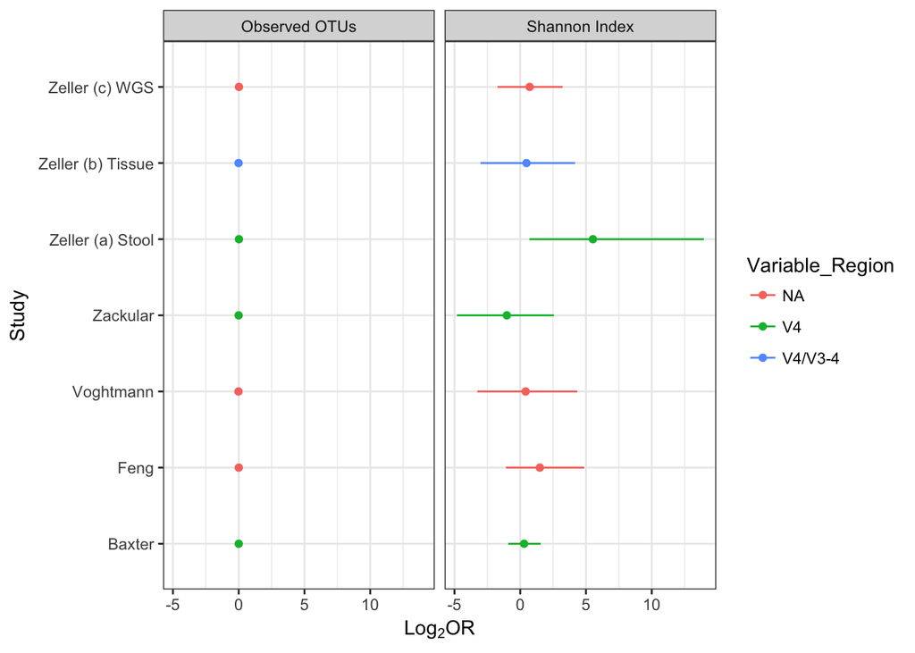

```r
ggplot(sum.dat, aes(OR, Study, col = Variable_Region)) + geom_point(aes(OR,
    Study, col = Variable_Region)) + geom_segment(aes(xend = UL, x = LL, y = Study,
    yend = Study, col = Variable_Region)) + facet_grid(. ~ alpha) + labs(x = expression(Log[2] *
    OR))
```

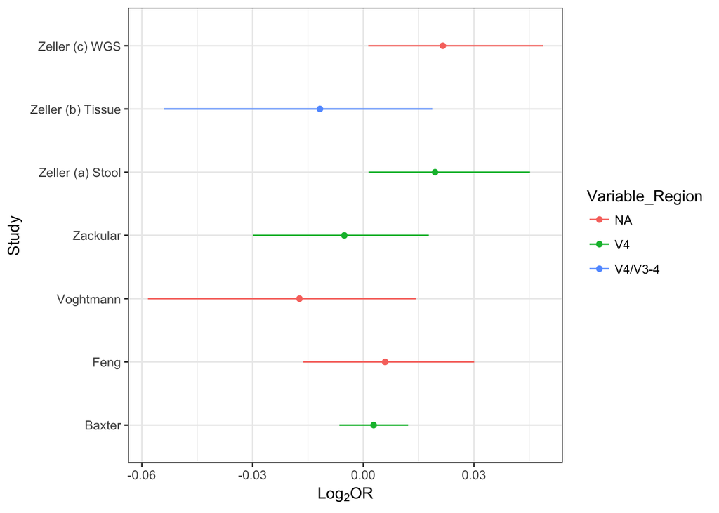

```r
# Note how small the x-axis scale is.
ggplot(sum.dat[sum.dat$alpha == "Observed OTUs", ], aes(OR, Study, col = Variable_Region)) +
    geom_point(aes(OR, Study, col = Variable_Region)) + geom_segment(aes(xend = UL,
    x = LL, y = Study, yend = Study, col = Variable_Region)) + labs(x = expression(Log[2] *
    OR))
```

## Multilevel logistic model

A multilevel logistic model may be more appropriate to answer the questions of the effects of variable region and sequencing method in obese individuals. So, even though I have yet to try a multilevel logistic regression model, I will do my best to fit the model and provide a reasonable interpretation of the results. The thing I am concerned about with using this analysis is the convergence of the model and the estimation of the standard errors. Because, the quality and accuracy of the estimates of standard errors in multilevel models is vastly affectly by sample size of each level 1 unit, i.e. number of individuals in each study.

The multilevel logistic regression model could look something like the following.

$$\log \left( \frac{ Pr(CRC = 1 ) }{ 1 - Pr(CRC = 1 )}\right) = \beta_{0j} + \beta_{1j} Alpha + \beta_{2j} Obese + \epsilon_{ij}$$

where $\beta_{0j}$ is the study specific intercept, $\beta_{1j}$ is the study specific regression coefficient i.e. the varying effect of alpha diversity of predicting the log OR of CRC, and $\beta_{2j}$ is the varying regression coefficient of the effect of being Obese. The inclusion of $\beta_{2j}$ instead of subsetting to solely the obese individuals allows for more accurate estimates of parameters due to the vast increase in sample size by including all individuals.

So, this is the level 1 (individual) model. The next piece is the building of the level 2 model, i.e. the model of the level 1 coefficents that vary by study.

$$\beta_{0j} = \gamma_{00} + \gamma_{01} Alpha + \gamma_{02} Obese + \gamma_{03} Seq.Method.16s + \gamma_{04} Var.Region.V4 + \gamma_{05} Var.Region.V34 + u_{0i}$$

$$\beta_{1j} = \gamma_{10} + \gamma_{11} Alpha + \gamma_{12} Obese + \gamma_{13} Seq.Method.16s + \gamma_{14} Var.Region.V4 + \gamma_{15} Var.Region.V34 + u_{1i}$$

$$\beta_{2j} = \gamma_{20} + \gamma_{21} Alpha + \gamma_{22} Obese + \gamma_{23} Seq.Method.16s + \gamma_{24} Var.Region.V4 + \gamma_{25} Var.Region.V34 + u_{2i}$$

where each $\gamma$ is the level 2 regression coefficient which allows for the estimate of a unique level 1 regression coefficient. The purpose of doing this complex model is to allow the estimates of the logit to me more precise when we estimate the logits for variable region and and sequencing type. The main result of this model is the extract the average log2 OR (logit) for each study when these different level 2 predictors are included in the model.

#### MLL Data Set-Up

```r
# Code the Study level predictors:
# Variable Region
pooled.dat$Var.Region.V4 <- ifelse(pooled.dat$Study == "Baxter" | pooled.dat$Study == "zackular" | pooled.dat$Study == "zeller.stool", 1,0)

pooled.dat$Var.Region.V34 <- ifelse(pooled.dat$Study == "zeller.tissue", 1,0)
  # Note that the baseline is the WGS where no primers were used

# Sequencing Method
pooled.dat$Seq.Method.16s <- ifelse( pooled.dat$Study == "Baxter" | pooled.dat$Study == "zackular" | pooled.dat$Study == "zeller.stool" | pooled.dat$Study == "zeller.tissue", 1,0) # 1 = 16S rRNA, 0 = WGS

# code gender as binary numeric
pooled.dat$female <- ifelse(pooled.dat$Gender == "female", 1, 0)
```

#### Running MLLs

```r
library(lme4)
library(arm)
fit1 <- glmer(CRC ~ Observed + Obese + ( 1 + Observed + Obese + Seq.Method.16s + Var.Region.V4 + Var.Region.V34 | Study),
            data = pooled.dat, family = binomial(link = "logit"))
display(fit1)
```

```
## glmer(formula = CRC ~ Observed + Obese + (1 + Observed + Obese +
##     Seq.Method.16s + Var.Region.V4 + Var.Region.V34 | Study),
##     data = pooled.dat, family = binomial(link = "logit"))
##             coef.est coef.se
## (Intercept) -0.30     0.23
## Observed     0.00     0.00
## Obese       -0.09     0.27
##
## Error terms:
##  Groups   Name           Std.Dev. Corr
##  Study    (Intercept)    0.23
##           Observed       0.00     -1.00
##           Obese          0.58      0.96 -0.97
##           Seq.Method.16s 0.32     -0.91  0.90 -0.80
##           Var.Region.V4  0.46     -0.78  0.80 -0.92  0.49
##           Var.Region.V34 1.64      0.23 -0.22  0.11 -0.20  0.03
##  Residual                1.00
## ---
## number of obs: 1221, groups: Study, 7
## AIC = 1549, DIC = 1456
## deviance = 1478.5
```

```r
# The following coefficients are the estimated gamma's and beta's from the above model. The big take away from these are the estimates of the effects of each study variable.
coef(fit1)
```

```
## $Study
##               Seq.Method.16s Var.Region.V4 Var.Region.V34 (Intercept)
## Baxter           -0.30008497   -0.52967996      0.0146084 -0.03720998
## Feng              0.37719537    0.58470187     -0.3453068 -0.61478203
## Voghtmann        -0.15821816   -0.18857602      0.2274096 -0.17544708
## zackular         -0.21037776   -0.35789214      0.1649849 -0.11519568
## zeller.stool     -0.03952763   -0.10427940     -0.0361644 -0.25714542
## zeller.tissue    -0.06196350   -0.05711541      0.5347450 -0.24679187
## zeller.wgs       -0.22954523   -0.34892561      0.2201979 -0.10647729
##                    Observed       Obese
## Baxter        -0.0018957093  0.61914094
## Feng           0.0001917723 -0.92300242
## Voghtmann     -0.0013912050  0.20586062
## zackular      -0.0016123514  0.39736362
## zeller.stool  -0.0011006694  0.03063440
## zeller.tissue -0.0011333500  0.01542275
## zeller.wgs    -0.0016422163  0.40574792
##
## attr(,"class")
## [1] "coef.mer"
```

```r
fit2 <- glmer(CRC ~ Shannon + Obese + ( 1 + Shannon + Obese + Seq.Method.16s + Var.Region.V4 + Var.Region.V34 | Study),
            data = pooled.dat, family = binomial(link = "logit"))
display(fit2)
```

```
## glmer(formula = CRC ~ Shannon + Obese + (1 + Shannon + Obese +
##     Seq.Method.16s + Var.Region.V4 + Var.Region.V34 | Study),
##     data = pooled.dat, family = binomial(link = "logit"))
##             coef.est coef.se
## (Intercept) -0.29     0.48
## Shannon     -0.02     0.17
## Obese       -0.17     0.28
##
## Error terms:
##  Groups   Name           Std.Dev. Corr
##  Study    (Intercept)    0.69
##           Shannon        0.20     -1.00
##           Obese          0.62      1.00 -1.00
##           Seq.Method.16s 0.64     -0.08  0.08 -0.08
##           Var.Region.V4  0.91     -0.72  0.72 -0.72 -0.63
##           Var.Region.V34 0.74      0.51 -0.51  0.51 -0.90  0.23
##  Residual                1.00
## ---
## number of obs: 1221, groups: Study, 7
## AIC = 1545.5, DIC = 1455.6
## deviance = 1476.6
```

```r
coef(fit2)
```

```
## $Study
##               Seq.Method.16s Var.Region.V4 Var.Region.V34 (Intercept)
## Baxter           -0.06456496    -0.7927897      0.4580029  0.54837734
## Feng              0.07245734     0.8879516     -0.5131867 -1.22801560
## Voghtmann        -0.02427583    -0.2978327      0.1720903  0.02531294
## zackular         -0.04952713    -0.6078461      0.3511941  0.35294739
## zeller.stool     -0.02525341    -0.3113982      0.1797417  0.03952477
## zeller.tissue    -0.03720765    -0.4527256      0.2620377  0.18931912
## zeller.wgs       -0.04645967    -0.5687863      0.3287948  0.31177924
##                  Shannon      Obese
## Baxter        -0.2614213  0.5821936
## Feng           0.2532586 -1.0062915
## Voghtmann     -0.1098722  0.1144590
## zackular      -0.2047988  0.4074362
## zeller.stool  -0.1139898  0.1271678
## zeller.tissue -0.1573903  0.2611161
## zeller.wgs    -0.1928710  0.3706226
##
## attr(,"class")
## [1] "coef.mer"
```

```r
# Put both together:
fit <- glmer(CRC ~ Observed + Shannon + Obese + ( 1 + Observed + Shannon + Obese + Seq.Method.16s + Var.Region.V4 + Var.Region.V34 | Study),
            data = pooled.dat, family = binomial(link = "logit"))
display(fit1)
```

```
## glmer(formula = CRC ~ Observed + Obese + (1 + Observed + Obese +
##     Seq.Method.16s + Var.Region.V4 + Var.Region.V34 | Study),
##     data = pooled.dat, family = binomial(link = "logit"))
##             coef.est coef.se
## (Intercept) -0.30     0.23
## Observed     0.00     0.00
## Obese       -0.09     0.27
##
## Error terms:
##  Groups   Name           Std.Dev. Corr
##  Study    (Intercept)    0.23
##           Observed       0.00     -1.00
##           Obese          0.58      0.96 -0.97
##           Seq.Method.16s 0.32     -0.91  0.90 -0.80
##           Var.Region.V4  0.46     -0.78  0.80 -0.92  0.49
##           Var.Region.V34 1.64      0.23 -0.22  0.11 -0.20  0.03
##  Residual                1.00
## ---
## number of obs: 1221, groups: Study, 7
## AIC = 1549, DIC = 1456
## deviance = 1478.5
```

##### Model Fit

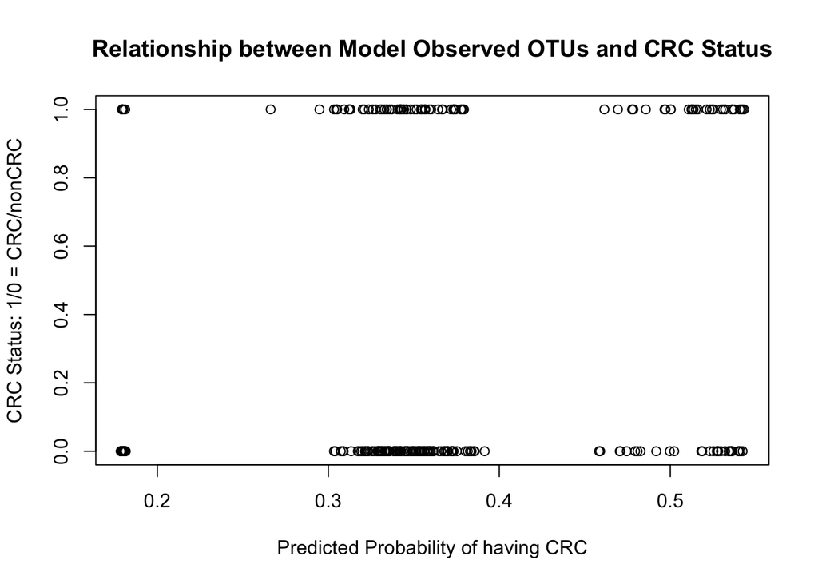

```r
fitted.Obs <- predict(fit1, pooled.dat)
log2fit.Obs <- log2(exp(fitted.Obs))
probfit.Obs <- exp(fitted.Obs)/(1+exp(fitted.Obs))

fitted.Shan <- predict(fit2, pooled.dat)
log2fit.Shan <- log2(exp(fitted.Shan))
probfit.Shan <- exp(fitted.Shan)/(1+exp(fitted.Shan))

pooled.dat <- cbind(pooled.dat, fitted.Obs, log2fit.Obs, probfit.Obs, fitted.Shan, log2fit.Shan, probfit.Shan)

# Plots of the estimated probabily by CRC Status

plot(pooled.dat$probfit.Obs[pooled.dat$Obese == 1],
     pooled.dat$CRC[pooled.dat$Obese == 1],
     xlab = "Predicted Probability of having CRC",
     ylab = "CRC Status: 1/0 = CRC/nonCRC",
     main = "Relationship between Model Observed OTUs and CRC Status")
```

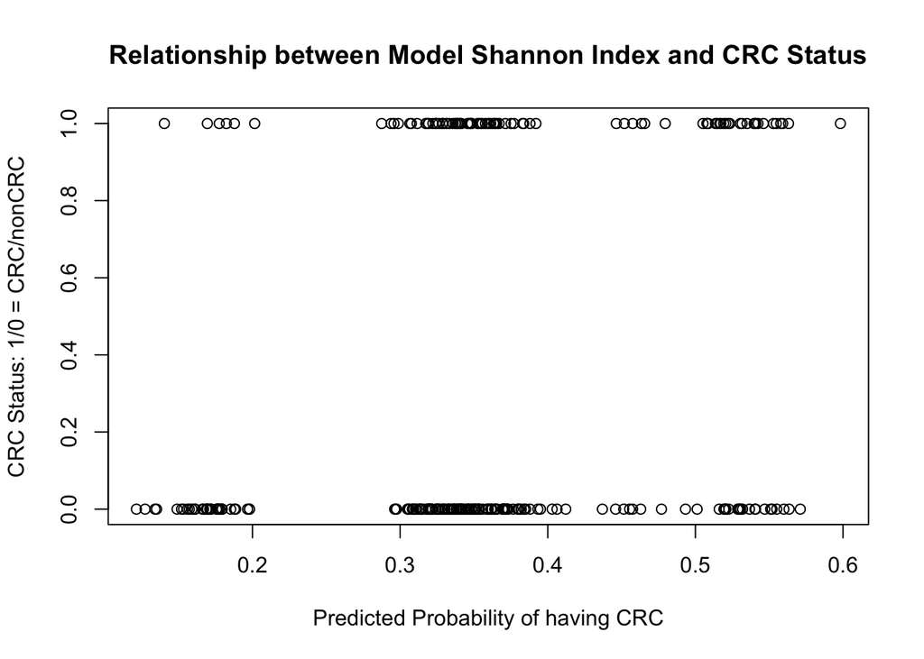

```r
plot(pooled.dat$probfit.Shan[pooled.dat$Obese == 1],
     pooled.dat$CRC[pooled.dat$Obese == 1],
     xlab = "Predicted Probability of having CRC",
     ylab = "CRC Status: 1/0 = CRC/nonCRC",
     main = "Relationship between Model Shannon Index and CRC Status")
```

#### Displaying model results

So, what I first did I don’t feel confident about about reviewing. Yes, what I did works, but I don’t think it gives the results I was intially thinking it did. The aim of the code below is the create confidence intervals around the effects of each study characteristic controlling for individuals with a constant estimate of alpha diversity.

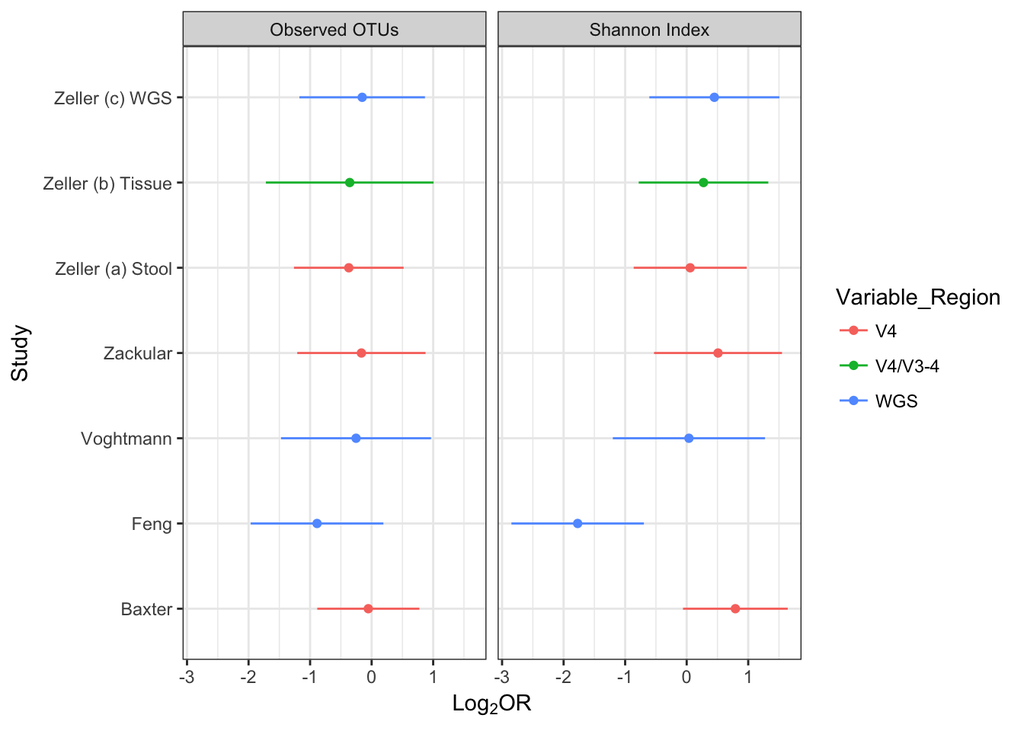

```r
# Need to get approximate estimates of standard errors:
# Observed OTUs
cc <- coef(fit1)$Study
## variances of fixed effects
fixed.vars <- diag(vcov(fit1))
## extract variances of conditional modes
r1 <- ranef(fit1,condVar=TRUE)
cmode.vars <- t(apply(cv <- attr(r1[[1]],"postVar"),3,diag))
seVals <- sqrt(sweep(cmode.vars,2,fixed.vars,"+"))
res <- cbind(cc,seVals)
res1 <- setNames(res[,c(4,9)], c("OR","OR_se"))
res1 <- log2(exp(res1))

# Shannon Diversity
cc <- coef(fit2)$Study
## variances of fixed effects
fixed.vars <- diag(vcov(fit2))
## extract variances of conditional modes
r1 <- ranef(fit2,condVar=TRUE)
cmode.vars <- t(apply(cv <- attr(r1[[1]],"postVar"),3,diag))
seVals <- sqrt(sweep(cmode.vars,2,fixed.vars,"+"))
res <- cbind(cc,seVals)
res2 <- setNames(res[,c(4,9)],c("OR","OR_se"))
res2 <- log2(exp(res2))

# Combine the results of the slope parameters to create LL and UL for CI
Study <- c("Baxter", "Feng", "Voghtmann","Zackular", "Zeller (a) Stool", "Zeller (b) Tissue", "Zeller (c) WGS")

Variable_Region <- c("V4", "WGS","WGS", "V4", "V4", "V4/V3-4", "WGS")
Extraction_Method <- c("16S rRNA/MiSeq", "WGS", "WGS", "16S rRNA", "16S rRNA", "16S rRNA", "WGS")

res1 <- cbind(res1, Study, Variable_Region, Extraction_Method, alpha = rep("Observed OTUs", 7))
res2 <- cbind(res2, Study, Variable_Region, Extraction_Method, alpha = rep("Shannon Index", 7))

results.stuff <- rbind(res1,res2)



# Make Plot
ggplot(results.stuff, aes(OR, Study)) +
  geom_point(aes(OR,Study, col = Variable_Region)) +
  geom_segment(aes(xend = OR + 1.96*OR_se, x = OR - 1.96*OR_se, y = Study,yend = Study, col = Variable_Region)) +
  facet_grid(.~alpha) +
  labs( x = expression(Log[2]*OR))
```

```r
ggsave("multilevel_logistic_parameter_plot.pdf", width =6, height = 4, units = "in")
```